# Tim Lindsey Data Exploration ggplot midwest data

## Overview

```
##       PID          county             state                area
##  Min.   : 561   Length:437         Length:437         Min.   :0.00500
##  1st Qu.: 670   Class :character   Class :character   1st Qu.:0.02400
##  Median :1221   Mode  :character   Mode  :character   Median :0.03000
##  Mean   :1437                                         Mean   :0.03317
##  3rd Qu.:2059                                         3rd Qu.:0.03800
##  Max.   :3052                                         Max.   :0.11000
##     poptotal         popdensity          popwhite          popblack
##  Min.   :   1701   Min.   :   85.05   Min.   :    416   Min.   :      0
##  1st Qu.:  18840   1st Qu.:  622.41   1st Qu.:  18630   1st Qu.:     29
##  Median :  35324   Median : 1156.21   Median :  34471   Median :    201
##  Mean   :  96130   Mean   : 3097.74   Mean   :  81840   Mean   :  11024
##  3rd Qu.:  75651   3rd Qu.: 2330.00   3rd Qu.:  72968   3rd Qu.:   1291
##  Max.   :5105067   Max.   :88018.40   Max.   :3204947   Max.   :1317147
##  popamerindian        popasian         popother        percwhite
##  Min.   :    4.0   Min.   :     0   Min.   :     0   Min.   :10.69
##  1st Qu.:   44.0   1st Qu.:    35   1st Qu.:    20   1st Qu.:94.89
##  Median :   94.0   Median :   102   Median :    66   Median :98.03
##  Mean   :  343.1   Mean   :  1310   Mean   :  1613   Mean   :95.56
##  3rd Qu.:  288.0   3rd Qu.:   401   3rd Qu.:   345   3rd Qu.:99.07
##  Max.   :10289.0   Max.   :188565   Max.   :384119   Max.   :99.82
##    percblack       percamerindan        percasian        percother
##  Min.   : 0.0000   Min.   : 0.05623   Min.   :0.0000   Min.   :0.00000
##  1st Qu.: 0.1157   1st Qu.: 0.15793   1st Qu.:0.1737   1st Qu.:0.09102
##  Median : 0.5390   Median : 0.21502   Median :0.2972   Median :0.17844
##  Mean   : 2.6763   Mean   : 0.79894   Mean   :0.4872   Mean   :0.47906
##  3rd Qu.: 2.6014   3rd Qu.: 0.38362   3rd Qu.:0.5212   3rd Qu.:0.48050
##  Max.   :40.2100   Max.   :89.17738   Max.   :5.0705   Max.   :7.52427
##    popadults          perchsd        percollege        percprof
##  Min.   :   1287   Min.   :46.91   Min.   : 7.336   Min.   : 0.5203
##  1st Qu.:  12271   1st Qu.:71.33   1st Qu.:14.114   1st Qu.: 2.9980
##  Median :  22188   Median :74.25   Median :16.798   Median : 3.8142
##  Mean   :  60973   Mean   :73.97   Mean   :18.273   Mean   : 4.4473
##  3rd Qu.:  47541   3rd Qu.:77.20   3rd Qu.:20.550   3rd Qu.: 4.9493
##  Max.   :3291995   Max.   :88.90   Max.   :48.079   Max.   :20.7913
##  poppovertyknown   percpovertyknown percbelowpoverty percchildbelowpovert
##  Min.   :   1696   Min.   :80.90    Min.   : 2.180   Min.   : 1.919
##  1st Qu.:  18364   1st Qu.:96.89    1st Qu.: 9.199   1st Qu.:11.624
##  Median :  33788   Median :98.17    Median :11.822   Median :15.270
##  Mean   :  93642   Mean   :97.11    Mean   :12.511   Mean   :16.447
##  3rd Qu.:  72840   3rd Qu.:98.60    3rd Qu.:15.133   3rd Qu.:20.352
##  Max.   :5023523   Max.   :99.86    Max.   :48.691   Max.   :64.308
##  percadultpoverty percelderlypoverty    inmetro         category
##  Min.   : 1.938   Min.   : 3.547     Min.   :0.0000   Length:437
##  1st Qu.: 7.668   1st Qu.: 8.912     1st Qu.:0.0000   Class :character
##  Median :10.008   Median :10.869     Median :0.0000   Mode  :character
##  Mean   :10.919   Mean   :11.389     Mean   :0.3432
##  3rd Qu.:13.182   3rd Qu.:13.412     3rd Qu.:1.0000
##  Max.   :43.312   Max.   :31.162     Max.   :1.0000
```

```
## Source: local data frame [6 x 28]
##
##     PID    county state  area poptotal popdensity popwhite popblack
##   (int)     (chr) (chr) (dbl)    (int)      (dbl)    (int)    (int)
## 1   561     ADAMS    IL 0.052    66090  1270.9615    63917     1702
## 2   562 ALEXANDER    IL 0.014    10626   759.0000     7054     3496
## 3   563      BOND    IL 0.022    14991   681.4091    14477      429
## 4   564     BOONE    IL 0.017    30806  1812.1176    29344      127
## 5   565     BROWN    IL 0.018     5836   324.2222     5264      547
## 6   566    BUREAU    IL 0.050    35688   713.7600    35157       50
## Variables not shown: popamerindian (int), popasian (int), popother (int),
##   percwhite (dbl), percblack (dbl), percamerindan (dbl), percasian (dbl),
##   percother (dbl), popadults (int), perchsd (dbl), percollege (dbl),
##   percprof (dbl), poppovertyknown (int), percpovertyknown (dbl),
##   percbelowpoverty (dbl), percchildbelowpovert (dbl), percadultpoverty
##   (dbl), percelderlypoverty (dbl), inmetro (int), category (chr)
```

first I’m interested in seeing the population data variance

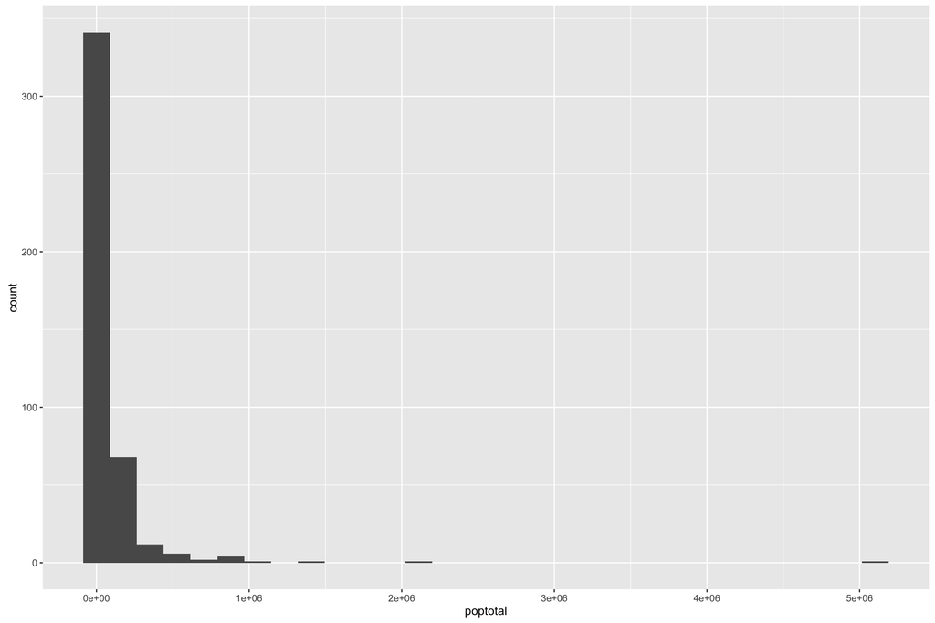

this view is a little messy. let me modify the x axis

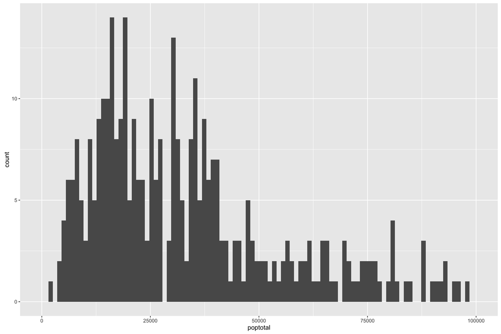

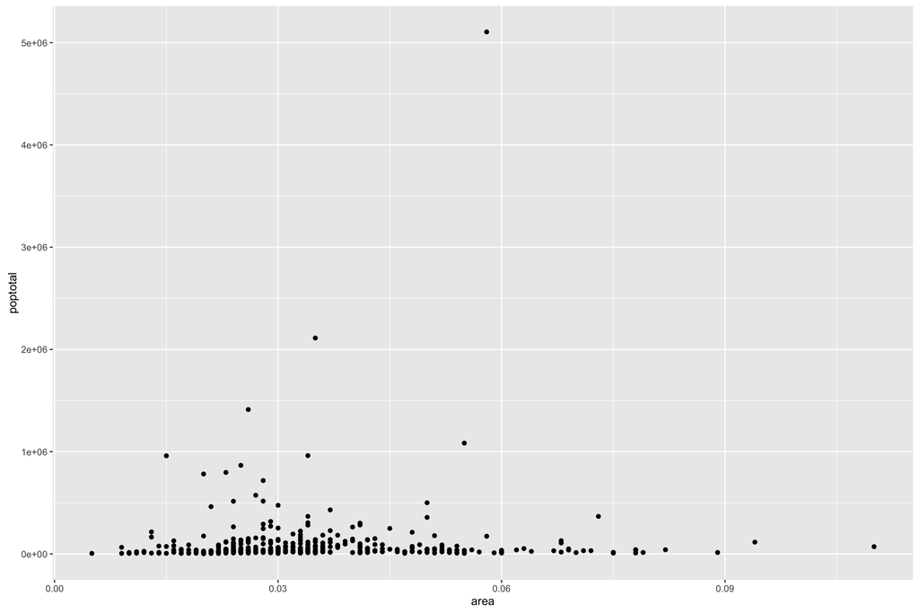

Interesting, but there are clearly some outliers. I wonder who is the datapoint with the excessively large population

```
## [1] "COOK"
```

based on county this is has to be Chicago. Let’s exclude that outlier and take another look

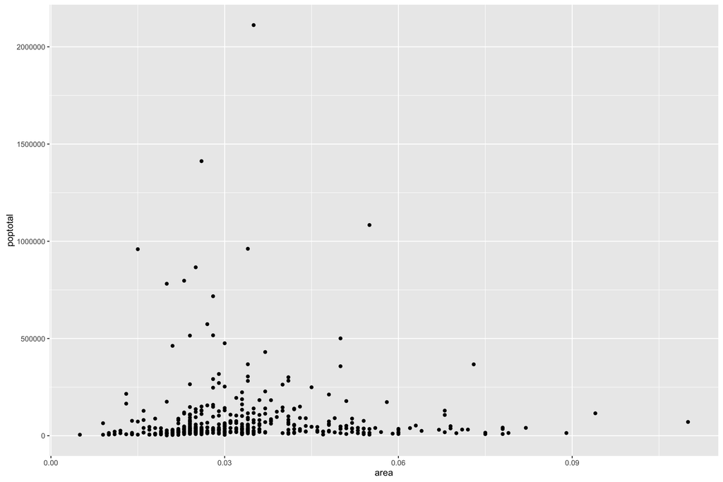

Even excluding the large datapoint there doesn’t seem to be a clear correlation between land area and population as you might think

taking a more abstract view at just population density:

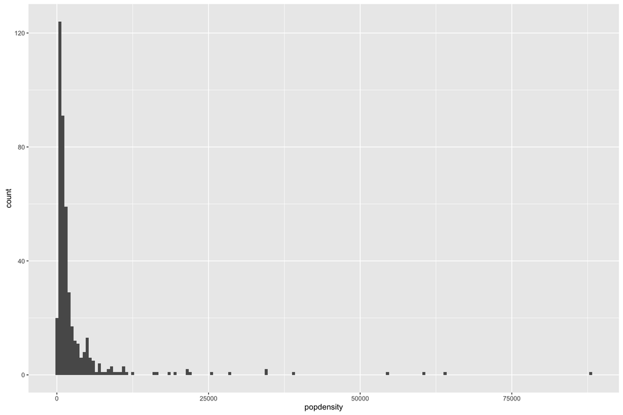

interesting, but I want to hone in on the densest area

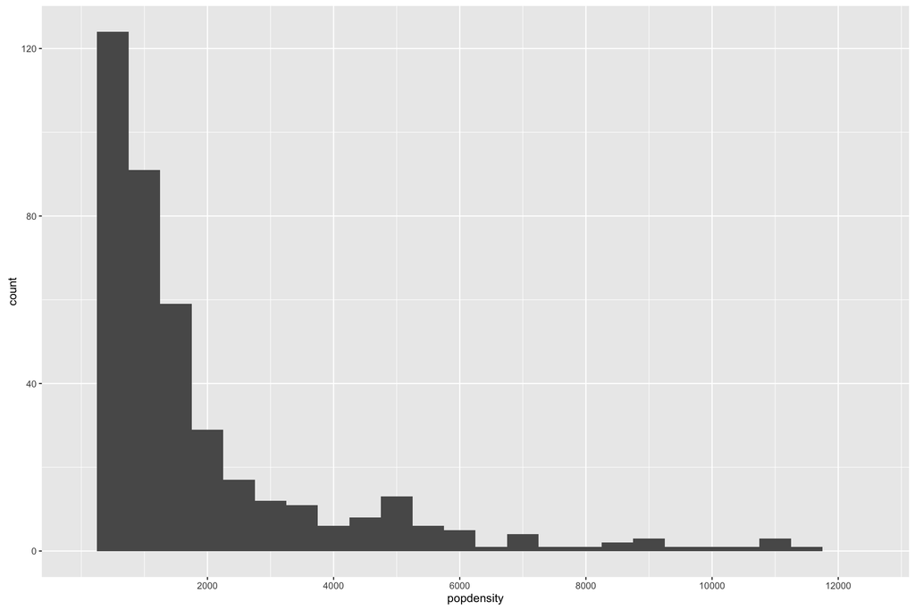

a little clearer where the activity is here, but I want to see the median (green) and mean (blue) as well

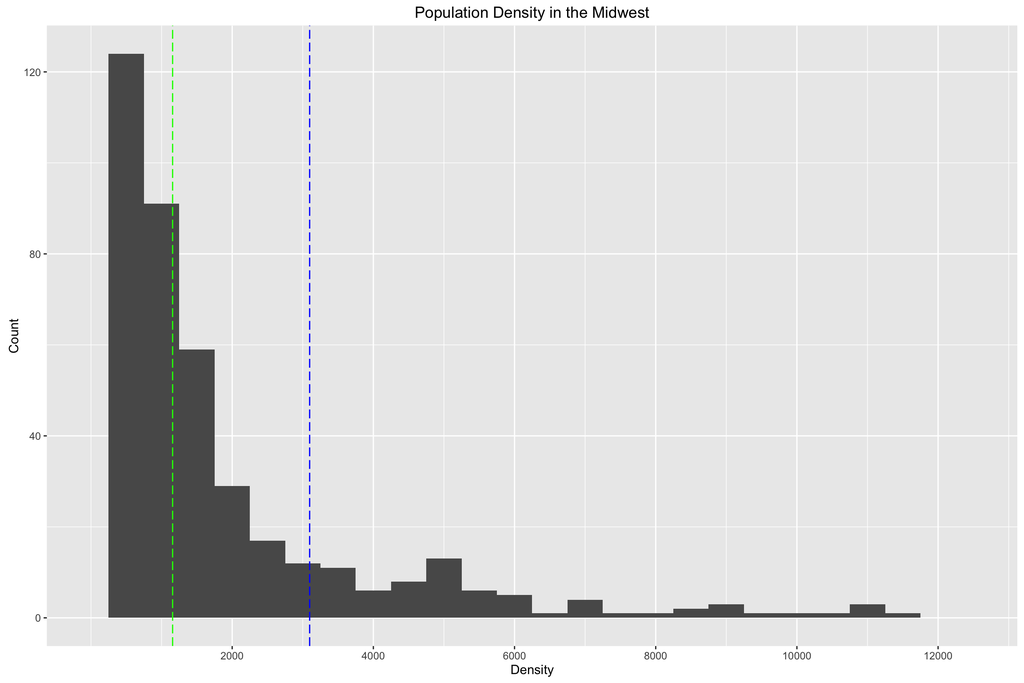

Next I’m interested to see if there’s a positive correlation between increased poverty (percentage wise) as population increases

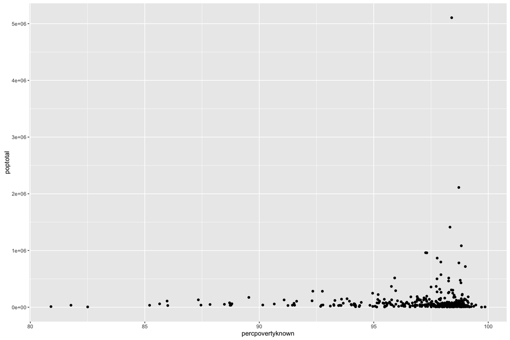

Let’s docus in more on the high in with the highest concentration

```
##      (Intercept) percpovertyknown
##      -277009.888         3842.438
```

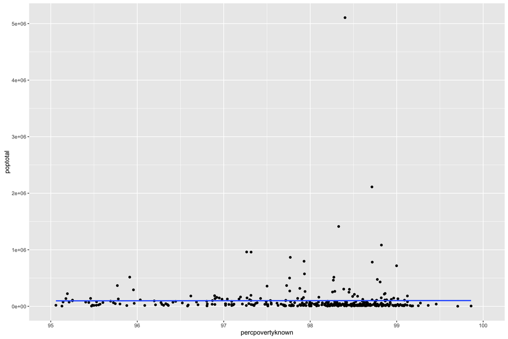

```
##
##  Pearson's product-moment correlation
##
## data:  midwest$percpovertyknown and midwest$poptotal
## t = 0.73956, df = 435, p-value = 0.46
## alternative hypothesis: true correlation is not equal to 0
## 95 percent confidence interval:
##  -0.05856266  0.12881319
## sample estimates:
##       cor
## 0.0354367
```

At best it’s a very weak positive correlation coversely I’d expect the percent in poverty to decrease as percent college educated increases.

```
## (Intercept)  percollege
##  99.2458309  -0.1168716
```

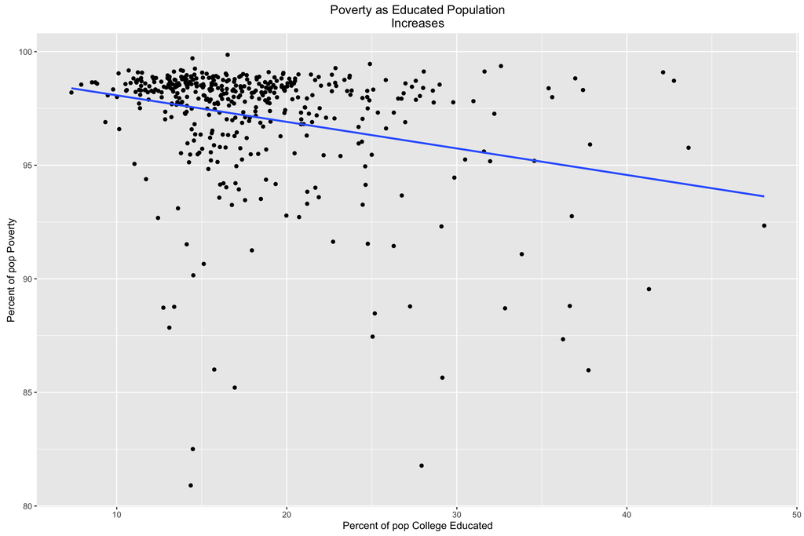

```
##
##  Pearson's product-moment correlation
##
## data:  midwest$percpovertyknown and midwest$percollege
## t = -5.7584, df = 435, p-value = 1.607e-08
## alternative hypothesis: true correlation is not equal to 0
## 95 percent confidence interval:
##  -0.3511743 -0.1767443
## sample estimates:
##        cor
## -0.2661366
```

I’m noticing that there’s 2 parameters: “percpovertynkown” and “percbelowpoverty” I want a total picture of poverty so I want to combine those values in to a new parameter “totalpercpoverty”

In hindsight this doesn’t appear to be how the percentages work, need to clear this column

Given poverty and race data I’d like to see a chart showing poverty as percent of each minority increases

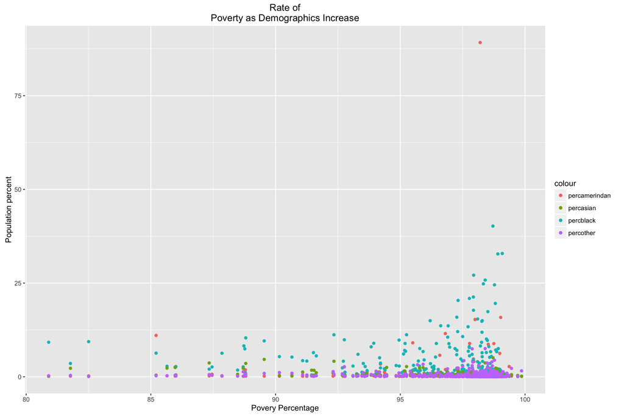

Based on what we know looking at previous graphs it seems likely a minority is also less likely to have by college educated

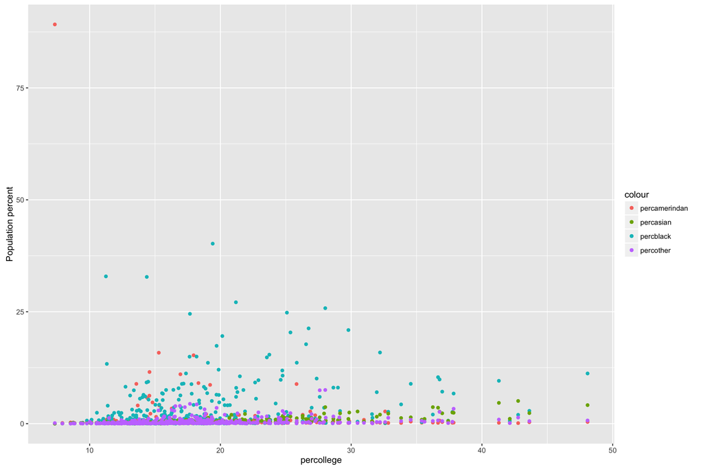

## Final plots and summary

Plot 1: Hostogram of population density in the midwest including median (green) and mean (blue) populations for entire dataset

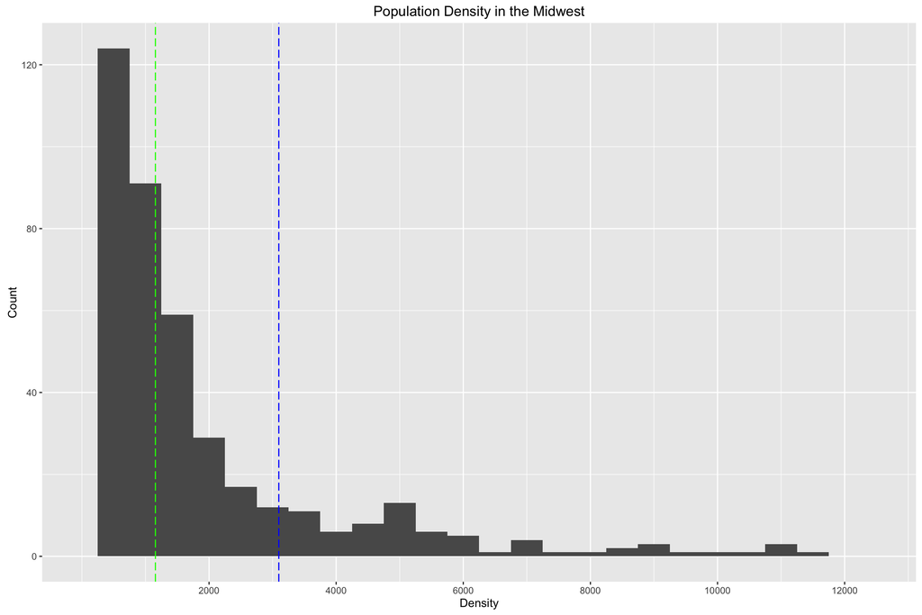

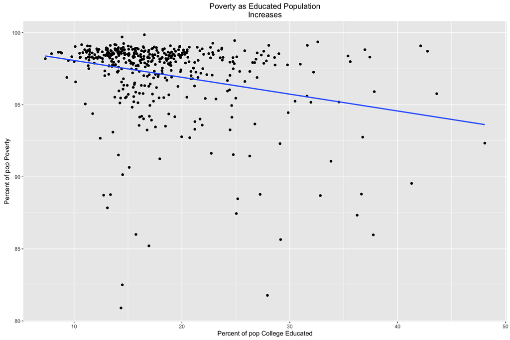

```
##
##  Pearson's product-moment correlation
##
## data:  midwest$percollege and midwest$percpovertyknown
## t = -5.7584, df = 435, p-value = 1.607e-08
## alternative hypothesis: true correlation is not equal to 0
## 95 percent confidence interval:
##  -0.3511743 -0.1767443
## sample estimates:
##        cor
## -0.2661366
```

Plot 3: Rate of poverty as percentage of particular minority populations increate in a county

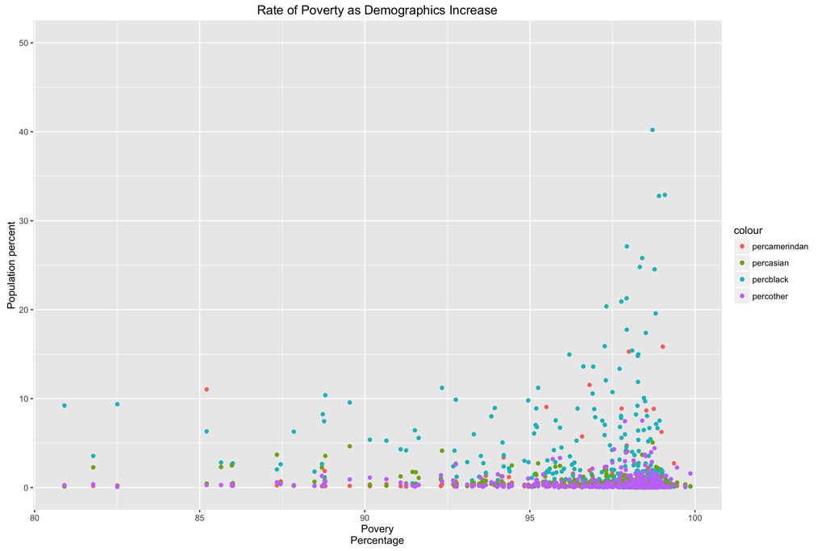

```
##
## Call:
## lm(formula = percpovertyknown ~ percblack + percasian + percother +
##     percamerindan, data = midwest)
##
## Residuals:
##      Min       1Q   Median       3Q      Max
## -16.5302  -0.3124   0.7347   1.2378   8.7902
##
## Coefficients:
##                Estimate Std. Error t value Pr(>|t|)
## (Intercept)   97.795927   0.165518 590.849  < 2e-16 ***
## percblack     -0.029887   0.025932  -1.153  0.24975
## percasian     -1.657034   0.212254  -7.807 4.47e-14 ***
## percother      0.433328   0.158207   2.739  0.00642 **
## percamerindan -0.007359   0.027094  -0.272  0.78606
## ---
## Signif. codes:  0 '***' 0.001 '**' 0.01 '*' 0.05 '.' 0.1 ' ' 1
##
## Residual standard error: 2.56 on 432 degrees of freedom
## Multiple R-squared:  0.1415, Adjusted R-squared:  0.1335
## F-statistic:  17.8 on 4 and 432 DF,  p-value: 1.543e-13
```

## Reflection

This is a fun exercise. It’s surprisingly difficult to find general data out in the wild that’s moderately well cleaned. The midwest dataset is interesting enough and well munged as part of the ggplot package. One of the most difficult things I’m finding is determining the most useful visualization type. In some places line bar and scatter visualizations all provide interesting accounts of the same data. One of the most interesting features of this dataset is it’s insight into poverty, it could be extremely useful to get insight into common precursors of poverty. However the only other real useful data points are around education and percentage of minorities. I suspect there are many other possible causes for poverty so the dataset isn’t quite as useful as it could be. Additional info such as crime rates in these counties could prove extremely valuable.